# StatComp Project 2: Scottish weather

Yichao Wang (s2056237)

# Seasonal variability

### Is precipitation seasonally varying?

We aim to investigate the variability of Scottish perception and temperature data across a span of approximately sixty years by first loading the data $\textbf{ghcnd_stations}$ and $\textbf{ghcnd_values}$, and then combine them with the `left_jiont` function into a new data frame called `ghcnd`. To facilitate analysis, a single year was selected for examination, specifically the year 2008. We filter the data on `Year == 2008` and create two plots to displaying the daily precipitation and temperature behaviors respectively.

Generally, we first focus on the analysis on precipitation data by filtering on `Element == "PRCP"`. The result is shown on scatter plot where each dot represent the precipitation data for the specific day and there is a smooth line in darkblue shows the monthly average precipitation across the whole year. To be more specific, the plot shows the result for each station by applying `facet_wrap` function.

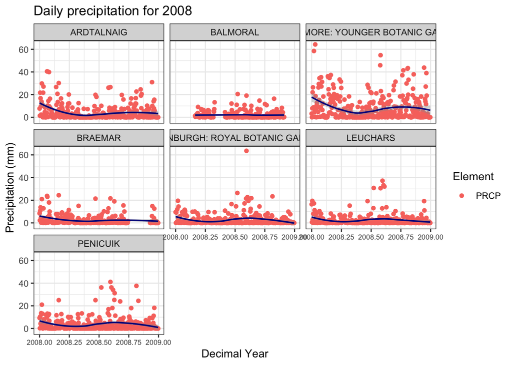

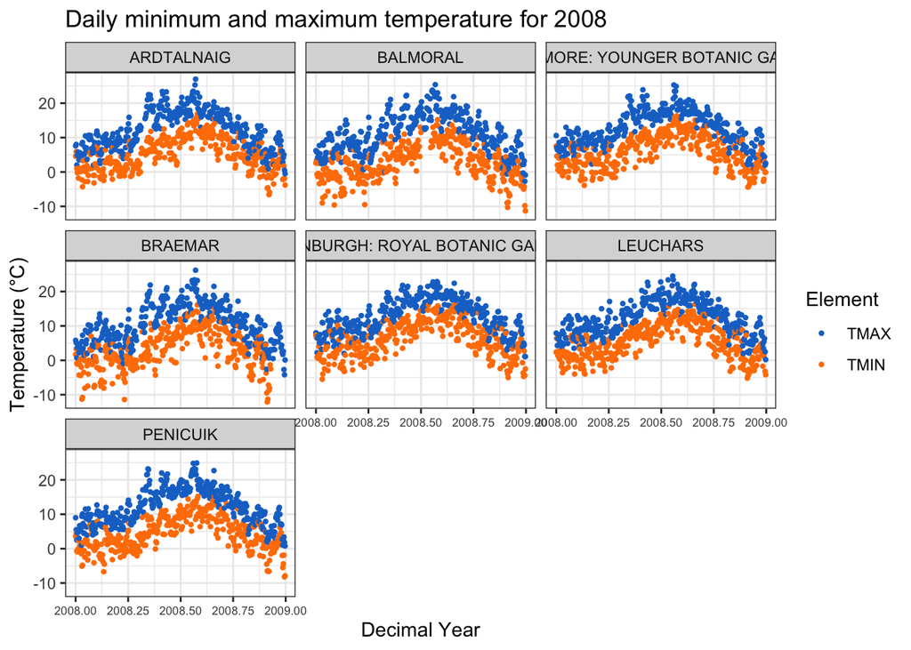

Similarly to the previous step for precipitation, we select the temperature data by filtering on `Element %in% c("TMAX", "TMIN")`. It is evident that there is a seasonal effect with the temperature being always higher in summer and lower in winter. this trend was observed in all stations which exactly coincide with the seasonal effect above.

To further analyze the precipitation, there is Monte Carlo permutation test for the hypotheses that we want to test:
$$\begin{align*}
& H_0: \text{The rainfall distribution is the same in winter as in
summer} \\
& H_1: \text{The winter and summer distributions have different
expected values}
\end{align*}$$
We define the test statistics as the absoluate value of the difference between average precipitation in winter and summer for each station respectively as $T = |\text{winter average} - \text{summer average}|$. For convinence, we add a $\textbf{Summer}$ column to the data that is $\textbf{TRUE}$ for summer month and $\textbf{FALSE}$ for winter month by the `mutate` function. We first calculate the test statistics $T$ for each station.

| Name | ID | winter_average | summer_average | T |
| --- | --- | --- | --- | --- |
| ARDTALNAIG | UKE00105884 | 4.679448 | 2.668042 | 2.0114061 |
| BALMORAL | UKE00105875 | 2.601891 | 1.994370 | 0.6075213 |
| BENMORE: YOUNGER BOTANIC GARDE | UKE00105930 | 8.353198 | 4.995383 | 3.3578143 |
| BRAEMAR | UKE00105874 | 2.878589 | 2.089790 | 0.7887997 |
| EDINBURGH: ROYAL BOTANIC GARDE | UKE00105888 | 1.869338 | 1.844564 | 0.0247740 |
| FASKALLY | UKE00105885 | 2.899627 | 2.130559 | 0.7690686 |
| LEUCHARS | UKE00105886 | 1.931070 | 1.809706 | 0.1213640 |
| PENICUIK | UKE00105887 | 2.751264 | 2.326199 | 0.4250654 |

| Name | p_value | monte_carlo_sd | lower_CI | upper_CI |
| --- | --- | --- | --- | --- |
| ARDTALNAIG | 0.0000 | 0.0000000 | 0.0000000 | 0.0003688 |
| BALMORAL | 0.0000 | 0.0000000 | 0.0000000 | 0.0003688 |
| BENMORE: YOUNGER BOTANIC GARDE | 0.0000 | 0.0000000 | 0.0000000 | 0.0003688 |
| BRAEMAR | 0.0000 | 0.0000000 | 0.0000000 | 0.0003688 |
| EDINBURGH: ROYAL BOTANIC GARDE | 0.6652 | 0.0047192 | 0.6559505 | 0.6744495 |
| FASKALLY | 0.0000 | 0.0000000 | 0.0000000 | 0.0003688 |
| LEUCHARS | 0.0310 | 0.0017332 | 0.0276030 | 0.0343970 |
| PENICUIK | 0.0000 | 0.0000000 | 0.0000000 | 0.0003688 |

Here we set $N=10000$ and rejected the null hypothesis for each station where the corresponding p-value is less than 0.05. The table shows that most stations have a p-value of zero, but EDINBURGH: ROYAL BOTANIC GARDE and LEUCHARS have positive p-values. Notably, the p-value for EDINBURGH: ROYAL BOTANIC GARDE is surprisingly large, which indicates that we failed to reject the null hypothesis of no seasonal difference in rainfall distribution. Conversely, for LEUCHARS, the p-value is positive but less than 0.05, allowing us to reject the null hypothesis. Therefore, except for EDINBURGH: ROYAL BOTANIC GARDE, we reject the null hypothesis for all stations, indicating that a seasonal difference in rainfall distribution exists at these seven stations.

# Spatial weather prediction

### Estimation and prediction

For the second part of the project, we begin by modifying our data frame with the code below. We calculate the square root of the monthly averaged precipitation value and store it as a new variable called $\textbf{Value_sqrt_avg}$. This generates a new data frame $\textbf{ghcnd_spatial}$.

```r
# Construct a version of the data set with a new variable, Value_sqrt_avg
# Subset the data to include only precipitation values
ghcnd_prcp<- ghcnd %>%
  filter(Element == "PRCP")
# Group by name, year, and month and compute the average value
ghcnd_spatial <- ghcnd_prcp %>%
  group_by(ID, Year, Month) %>%
  summarise(DecYear = mean(DecYear), Value_monthly = mean(Value), .groups = "drop") %>%
  mutate(Value_sqrt_avg = sqrt(Value_monthly))
```

Now there is a basic model for the square root of monthly average precipitation defined as
$$M_0: \text{Value_sqrt_avg} \sim \text{Intercept + Longtitude + Latitude
+ Elevation + DecYear}$$
Then by adding covariates $\cos{(2\pi kt)}$ and $\sin{(2\pi kt)}$ of frequencey $k=1,2,3$… we can also model the seasonal variability, defining four models $M_1$, $M_2$, $M_3$, and $M_4$, where the predictor expression for model $M_K$ adds
$$\sum_{k=1}^{K} [\gamma_{c,k} \cos{(2\pi kt)} + \gamma_{s,k} \sin{(2\pi
kt)}]$$
to the $M_0$ predictor expression, for the model coefficient $\gamma_{c,k}$ and $\gamma_{s,k}$. Moreover, the time $t$ here is defined to be the $\textbf{DecYear}$.

Now we aim to estimate the model parameters for all five models. We defined the function `fit_model` which takes the value of the corresponding data frame and the value of k, which respond to each model, and return the result of the fitted model. Further, with the help of `summary` function, we finally obtain the estimation of parameters for all models.

|  | Estimate | Std. Error | t value | Pr(>\|t\|) |
| --- | --- | --- | --- | --- |
| (Intercept) | 2.4769477 | 1.3942775 | 1.776510 | 0.0757048 |
| Longitude | -0.5464155 | 0.0107287 | -50.930197 | 0.0000000 |
| Latitude | -0.1359610 | 0.0201820 | -6.736743 | 0.0000000 |
| Elevation | 0.0004022 | 0.0000769 | 5.230763 | 0.0000002 |
| DecYear | 0.0024109 | 0.0003968 | 6.076437 | 0.0000000 |

Then for the rest four models, additional coefficients for the cosine and sine functions are also included. These two coefficients represent the estimated change in the square root of monthly average precipitation for a 1 unit increase in time for a specific frequency of the $\cos$ and $\sin$ functions. To be more detailed, for model $M_1$, with frequency $k=1$, the estimate for $\cos$ is about 0.183, which suggests that there is a increase in precipitation. Then for other models $M_2, M_3$ and $M_4$, we can generate the similar result as this with additional coefficients for higher frequency of the $\cos$ and $\sin$ functions. The table below shows the result for the estimation of parameters for the rest four models.

For $M_1$model

|  | Estimate | Std. Error | t value | Pr(>\|t\|) |
| --- | --- | --- | --- | --- |
| (Intercept) | 2.4899466 | 1.3190655 | 1.887660 | 0.0591249 |
| Longitude | -0.5466656 | 0.0101494 | -53.861761 | 0.0000000 |
| Latitude | -0.1349611 | 0.0190924 | -7.068842 | 0.0000000 |
| Elevation | 0.0004040 | 0.0000727 | 5.554431 | 0.0000000 |
| DecYear | 0.0023757 | 0.0003754 | 6.328596 | 0.0000000 |
| cos(2 * pi * 1 * DecYear) | 0.1828141 | 0.0089020 | 20.536227 | 0.0000000 |
| sin(2 * pi * 1 * DecYear) | -0.1320307 | 0.0088699 | -14.885257 | 0.0000000 |

For $M_2$ model

|  | Estimate | Std. Error | t value | Pr(>\|t\|) |
| --- | --- | --- | --- | --- |
| (Intercept) | 2.4768245 | 1.3178582 | 1.8794316 | 0.0602390 |
| Longitude | -0.5466570 | 0.0101400 | -53.9107744 | 0.0000000 |
| Latitude | -0.1349497 | 0.0190748 | -7.0747777 | 0.0000000 |
| Elevation | 0.0004042 | 0.0000727 | 5.5617875 | 0.0000000 |
| DecYear | 0.0023820 | 0.0003750 | 6.3512162 | 0.0000000 |
| cos(2 * pi * 1 * DecYear) | 0.1829270 | 0.0088941 | 20.5672844 | 0.0000000 |
| sin(2 * pi * 1 * DecYear) | -0.1320672 | 0.0088618 | -14.9030438 | 0.0000000 |
| cos(2 * pi * 2 * DecYear) | 0.0308837 | 0.0088891 | 3.4743492 | 0.0005161 |
| sin(2 * pi * 2 * DecYear) | 0.0007686 | 0.0088659 | 0.0866895 | 0.9309215 |

For $M_3$ model

|  | Estimate | Std. Error | t value | Pr(>\|t\|) |
| --- | --- | --- | --- | --- |
| (Intercept) | 2.4704214 | 1.3167785 | 1.8761100 | 0.0606937 |
| Longitude | -0.5466809 | 0.0101317 | -53.9575739 | 0.0000000 |
| Latitude | -0.1349466 | 0.0190591 | -7.0804395 | 0.0000000 |
| Elevation | 0.0004044 | 0.0000726 | 5.5697391 | 0.0000000 |
| DecYear | 0.0023850 | 0.0003747 | 6.3644191 | 0.0000000 |
| cos(2 * pi * 1 * DecYear) | 0.1827885 | 0.0088870 | 20.5681356 | 0.0000000 |
| sin(2 * pi * 1 * DecYear) | -0.1320662 | 0.0088546 | -14.9150677 | 0.0000000 |
| cos(2 * pi * 2 * DecYear) | 0.0307235 | 0.0088820 | 3.4590838 | 0.0005462 |
| sin(2 * pi * 2 * DecYear) | 0.0005964 | 0.0088587 | 0.0673209 | 0.9463287 |
| cos(2 * pi * 3 * DecYear) | -0.0070723 | 0.0088684 | -0.7974687 | 0.4252137 |
| sin(2 * pi * 3 * DecYear) | 0.0285383 | 0.0088721 | 3.2166209 | 0.0013047 |

For $M_4$ model

|  | Estimate | Std. Error | t value | Pr(>\|t\|) |
| --- | --- | --- | --- | --- |
| (Intercept) | 2.4712330 | 1.3165058 | 1.8771151 | 0.0605559 |
| Longitude | -0.5466744 | 0.0101296 | -53.9681005 | 0.0000000 |
| Latitude | -0.1349674 | 0.0190551 | -7.0829934 | 0.0000000 |
| Elevation | 0.0004042 | 0.0000726 | 5.5682896 | 0.0000000 |
| DecYear | 0.0023852 | 0.0003747 | 6.3663294 | 0.0000000 |
| cos(2 * pi * 1 * DecYear) | 0.1828520 | 0.0088857 | 20.5783195 | 0.0000000 |
| sin(2 * pi * 1 * DecYear) | -0.1320498 | 0.0088528 | -14.9162192 | 0.0000000 |
| cos(2 * pi * 2 * DecYear) | 0.0307010 | 0.0088803 | 3.4572014 | 0.0005500 |
| sin(2 * pi * 2 * DecYear) | 0.0006781 | 0.0088570 | 0.0765625 | 0.9389744 |
| cos(2 * pi * 3 * DecYear) | -0.0070451 | 0.0088668 | -0.7945515 | 0.4269092 |
| sin(2 * pi * 3 * DecYear) | 0.0284900 | 0.0088705 | 3.2117859 | 0.0013268 |
| cos(2 * pi * 4 * DecYear) | 0.0135609 | 0.0088998 | 1.5237317 | 0.1276339 |
| sin(2 * pi * 4 * DecYear) | 0.0122274 | 0.0088379 | 1.3835220 | 0.1665617 |

### Assessment: Station and season differences

To do the further investigation, we are looking for how well the model can predict precipitation at new location by constructing a stratified corss-validation. Here we define the `stratified_cv` function which takes two parameters, data frame and the value of k, which define one of the five models. The function will return a 96*5 dataframe shows the average SE and DS scores for each month by station after the corss validation process, including the Name, ID, Month, and its corresponding standard error scores(SE) and Dawid-Sebastiani scores(DS). Since there are 8 stations and 12 months, each of the five models will have exactly one result with $8 \times 12 = 96$ rows. Thus, there will be a total of $96\times 5 = 480$ rows across all five models, which means a total of $2 \times 480 = 960$ number of values of scores(480 for SE score and 480 for DS scores).

For example, when choose $k=1$, the result will return a table with 96 rows.

```r
stratified_cv(ghcnd_data, 1)
```

```
## # A tibble: 96 × 5
##    ID          Name    Month     se     ds
##    <chr>       <chr>   <int>  <dbl>  <dbl>
##  1 UKE00105874 BRAEMAR     1 0.185  -0.672
##  2 UKE00105874 BRAEMAR     2 0.159  -0.784
##  3 UKE00105874 BRAEMAR     3 0.0957 -1.07
##  4 UKE00105874 BRAEMAR     4 0.153  -0.811
##  5 UKE00105874 BRAEMAR     5 0.128  -0.924
##  6 UKE00105874 BRAEMAR     6 0.107  -1.02
##  7 UKE00105874 BRAEMAR     7 0.121  -0.958
##  8 UKE00105874 BRAEMAR     8 0.184  -0.675
##  9 UKE00105874 BRAEMAR     9 0.194  -0.629
## 10 UKE00105874 BRAEMAR    10 0.194  -0.629
## # … with 86 more rows
```

Moreover, we calculated the overall corss-validated average scores for each station with five models and hence get the result of a table of $5 \times 8 = 40$ rows.

| Name | ID | k | average_se | average_ds |
| --- | --- | --- | --- | --- |
| ARDTALNAIG | UKE00105884 | 0 | 0.3394895 | 0.0137910 |
| ARDTALNAIG | UKE00105884 | 1 | 0.2857313 | -0.1925078 |
| ARDTALNAIG | UKE00105884 | 2 | 0.2850669 | -0.1952184 |
| ARDTALNAIG | UKE00105884 | 3 | 0.2838975 | -0.2006504 |
| ARDTALNAIG | UKE00105884 | 4 | 0.2837743 | -0.2012508 |
| BALMORAL | UKE00105875 | 0 | 0.1830942 | -0.6544201 |
| BALMORAL | UKE00105875 | 1 | 0.1681612 | -0.7466475 |
| BALMORAL | UKE00105875 | 2 | 0.1683259 | -0.7463112 |
| BALMORAL | UKE00105875 | 3 | 0.1684852 | -0.7459532 |
| BALMORAL | UKE00105875 | 4 | 0.1683211 | -0.7466557 |
| BENMORE: YOUNGER BOTANIC GARDE | UKE00105930 | 0 | 0.6791761 | 1.8180702 |
| BENMORE: YOUNGER BOTANIC GARDE | UKE00105930 | 1 | 0.6015445 | 1.6145002 |
| BENMORE: YOUNGER BOTANIC GARDE | UKE00105930 | 2 | 0.6026575 | 1.6275220 |
| BENMORE: YOUNGER BOTANIC GARDE | UKE00105930 | 3 | 0.6020913 | 1.6278410 |
| BENMORE: YOUNGER BOTANIC GARDE | UKE00105930 | 4 | 0.6022941 | 1.6294953 |
| BRAEMAR | UKE00105874 | 0 | 0.1788729 | -0.6715428 |
| BRAEMAR | UKE00105874 | 1 | 0.1546528 | -0.8056632 |
| BRAEMAR | UKE00105874 | 2 | 0.1545635 | -0.8065269 |
| BRAEMAR | UKE00105874 | 3 | 0.1539896 | -0.8094017 |
| BRAEMAR | UKE00105874 | 4 | 0.1537592 | -0.8103960 |
| EDINBURGH: ROYAL BOTANIC GARDE | UKE00105888 | 0 | 0.1810967 | -0.6604515 |
| EDINBURGH: ROYAL BOTANIC GARDE | UKE00105888 | 1 | 0.1957361 | -0.6240794 |
| EDINBURGH: ROYAL BOTANIC GARDE | UKE00105888 | 2 | 0.1949797 | -0.6276371 |
| EDINBURGH: ROYAL BOTANIC GARDE | UKE00105888 | 3 | 0.1949997 | -0.6277090 |
| EDINBURGH: ROYAL BOTANIC GARDE | UKE00105888 | 4 | 0.1948990 | -0.6281629 |
| FASKALLY | UKE00105885 | 0 | 0.2345134 | -0.4496457 |
| FASKALLY | UKE00105885 | 1 | 0.2134083 | -0.5443998 |
| FASKALLY | UKE00105885 | 2 | 0.2122443 | -0.5497812 |
| FASKALLY | UKE00105885 | 3 | 0.2115041 | -0.5532186 |
| FASKALLY | UKE00105885 | 4 | 0.2114887 | -0.5532911 |
| LEUCHARS | UKE00105886 | 0 | 0.2867391 | -0.2372317 |
| LEUCHARS | UKE00105886 | 1 | 0.2974184 | -0.1561131 |
| LEUCHARS | UKE00105886 | 2 | 0.2965283 | -0.1598262 |
| LEUCHARS | UKE00105886 | 3 | 0.2963989 | -0.1599333 |
| LEUCHARS | UKE00105886 | 4 | 0.2962063 | -0.1608558 |
| PENICUIK | UKE00105887 | 0 | 0.1800883 | -0.6651038 |
| PENICUIK | UKE00105887 | 1 | 0.1748678 | -0.7167632 |
| PENICUIK | UKE00105887 | 2 | 0.1742859 | -0.7196454 |
| PENICUIK | UKE00105887 | 3 | 0.1743311 | -0.7197466 |
| PENICUIK | UKE00105887 | 4 | 0.1742530 | -0.7200933 |

In the table, we can see that the value of the SE score and DS score for each station is quite similar across models $M_1$, $M_2$, $M_3$, and $M_4$, but for model $M_0$ they are quiet different. To view the difference more intuitively, we can create two subplots, one for the SE score and one for the DS score, to find out whether the models are equally effective at predicting the different stations.

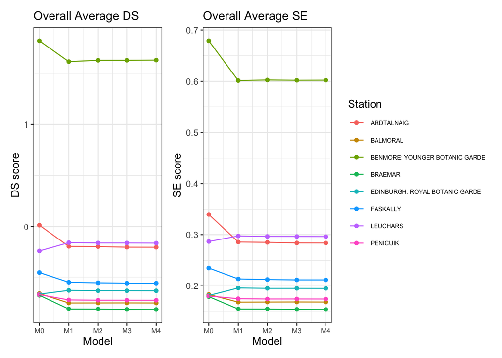

To further investigate whether the prediction accuracy is consistent throughout the year, we generate two plots that display the monthly average values of the two scores for each station of five models.

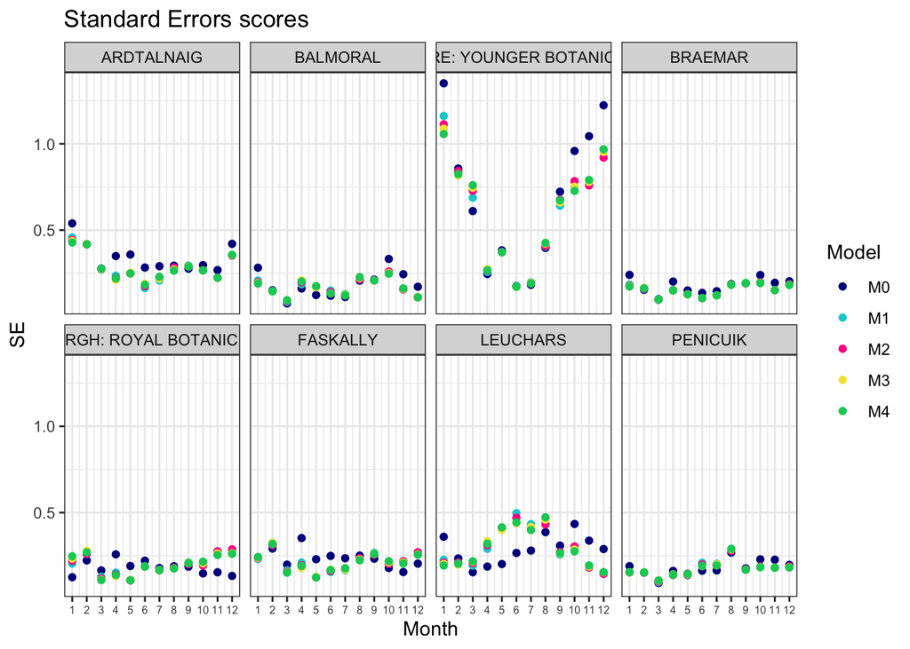

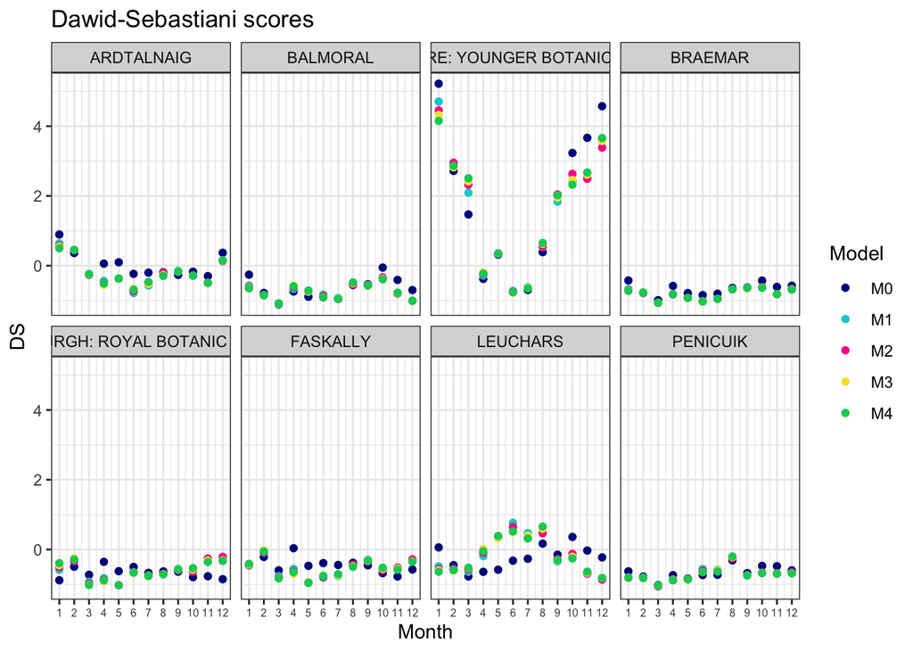

# Code appendix

Quick-running code can instead be placed directly in the `.Rmd` file.

| A | B |
| --- | --- |
| 467.2 | 321.5946 |

## Function definitions

```r
# Yichao Wang (s2056237)

# Place your function definitions that may be needed in the report.Rmd, including function documentation.
# You can also include any needed library() calls here
library(StatCompLab)
library(tidyverse)
library(ggplot2)
library(patchwork)
library(knitr)
library(dplyr)

###################

#' P-value and confidence interval
#' Construct the 95% confidence interval for each station
#'
#' The result will return a table includes the Name, p-value,
#' Monte Carlo standard deviation, and the CI for each station.
#'
#' @param data the desired data to be put into model
#' @param alpha the value of alpha, here we take 0.05 to construct a 95% CI
#' @param N the number of permutations
#'

p_value_CI <- function(data, alpha=0.05, N=10000) {
  # Initialize the count to be zero for each test statistic
  count <- rep(0, length = length(T_stats))
  for (n in 1:N) {
    # Generate a random permutation of the indices
    permutation <- sample(data$Summer, length(data$Summer), replace = FALSE)
    # Apply the permutation to the data and group by weather station
    ghcnd_permutation <- data %>%
      mutate("Summer" = permutation) %>%
      group_by(Name)
    # Compute the test statistic for the permuted data
    ghcnd_permutated <- ghcnd_permutation %>%
      summarise(Value = abs(mean(Value[Summer]) - mean(Value[!Summer])), .groups = "drop")
    # add one to the count if the test statistic is less than or equal to the observed value
    count <- count + (ghcnd_permutated$Value >= T_stats)
  }

  # Compute the p-value and Monte Carlo standard deviation
  p_value <- count / N
  monte_carlo_sd <- sqrt(p_value * (1 - p_value) / N)

  # Compute confidence interval for p-value
  lower_CI <- numeric(length(p_value))
  upper_CI <- numeric(length(p_value))
  for (i in 1:length(p_value)) {
    if (p_value[i] > 0) { # When x > 0 (p_value>0)
      lower_CI[i] <- p_value[i] - qnorm(1 - alpha/2) * monte_carlo_sd[i]
      upper_CI[i] <- p_value[i] + qnorm(1 - alpha/2) * monte_carlo_sd[i]
    } else { # When x = 0, CI=(0, 1-0.0025^(1/N))
      lower_CI[i] <- 0
      upper_CI[i] <- 1 - 0.025^(1/N)
    }
  }

  # Store the result in a dataframe and show them as a table
  result_table <- data.frame(Name = unique(winter_avg$Name),
                             p_value = p_value,
                             monte_carlo_sd = monte_carlo_sd,
                             lower_CI = lower_CI,
                             upper_CI = upper_CI)
  return(kable(result_table, align = "lcccc"))
}




#' Estimate models for the square root of the
#' monthly averaged precipitation values in Scotland
#'
#' The result will return the fitted model for five different
#' model M0, M1, M2, M3, M4 as different value of k entered
#'
#' @param data the desired data to be put into model
#' @param k the model M_k(k from 0 to 4)
#'

fit_model <- function(data, k) {
  # Define the formula for the model
  if(k == 0) { # When k = 0
    model <- Value_sqrt_avg ~ Longitude + Latitude + Elevation + DecYear
  } else{ # When k = 1,2,3,4
    model <- formula(paste0("Value_sqrt_avg ~ Longitude + Latitude + Elevation + DecYear + ",
                            paste0("cos(2*pi*", seq(1, k), "*DecYear) + sin(2*pi*", seq(1, k), "*DecYear)",
                                   collapse = " + ")))
  }
  # Fit the linear model
  fit <- lm(model, data = data)

  # Return the model object
  return(fit)
}




#' Stratified cross validation function
#'
#' The result will return a 96*5 dataframe shows the average SE and DS scores for each
#' month by station after the corss validation process, including the Name, ID, Month,
#' and its corresponding standard error scores(SE) and Dawid-Sebastiani scores(DS).
#'
#' since there are 8 stations and 12 months, we got a total of 12*8=96 rows.
#'
#' @param data the desired data to do the corss validation
#' @param k the model M_k(k from 0 to 4)

stratified_cv <- function(data, k) {
  pred2 <- data %>% mutate(mean = NA_real_, sd = NA_real_)
  for (id in unique(data$ID)) {
    if(k == 0) { # When k = 0
      model <- Value_sqrt_avg ~ Longitude + Latitude + Elevation + DecYear
    } else{ # When k = 1,2,3,4
      model <- formula(paste0("Value_sqrt_avg ~ Longitude + Latitude + Elevation + DecYear + ",
                              paste0("cos(2*pi*", seq(1, k), "*DecYear) + sin(2*pi*", seq(1, k), "*DecYear)",
                                     collapse = " + ")))
    }
    # fit and predict the model for the data
    fit <- lm(model, data %>% filter(ID != id))
    pred <- predict(fit, newdata = data %>% filter(ID == id), se.fit = TRUE)
    # evaluate the mean and sd
    pred2$mean[(pred2$ID == id)] <- pred$fit
    pred2$sd[(pred2$ID == id)] <- sqrt((pred$se.fit)^2 + (pred$residual.scale)^2)
    # mutate the table
    pred2 <- pred2 %>%
      group_by(ID, Name, Year, Month) %>%
      mutate(se = proper_score("se", Value_sqrt_avg, mean = mean),
             ds = proper_score("ds", Value_sqrt_avg, mean = mean, sd = sd))
  }
  # Calculate the average score for each month
  Average_score <- pred2 %>%
    group_by(ID, Name, Month) %>%
    summarise(se = mean(se), ds = mean(ds), .groups = "drop")
  return(Average_score)
}
```